# 1. Adatkészlet betöltése

```python
import pandas as pd
import numpy as np
from ydata_profiling import ProfileReport
import matplotlib.pyplot as plt
import seaborn as sns
from sklearn.preprocessing import StandardScaler
from sklearn.preprocessing import MinMaxScaler
import tensorflow as tf
from tensorflow import keras
from tensorflow.keras import layers, activations
from keras.callbacks import EarlyStopping, ModelCheckpoint
%matplotlib inline

# Fájlok beolvasása - a notebook és a fájlok egy mappában kaptak helyet, az egyszerűség kedvééért
df1 = pd.read_csv("car_sales1.csv")
df2 = pd.read_csv("car_sales2.csv")
df3 = pd.read_csv("car_sales3.csv")

# Single dataframe
df = pd.concat([df1, df2, df3], ignore_index=True)

# Átnevezem az oszlopokat az egyértelmű beazonosíthatóság érdekében és a magyarázatok során a magyar nevükkel fogok hivatkozni rájuk
df = df.rename(columns={
    'date': 'Eladási dátum',
    'city': 'Város',
    'salesperson': 'Értékesítő',
    'customername': 'Vásárló neve',
    'carmake': 'Autómárka',
    'carmodel': 'Autómodell',
    'caryear': 'Gyártási év',
    'saleprice': 'Eladási ár',
    'commissionrate': 'Jutalékszázalék',
    'commisionearned': 'Megszerzett jutalék'
})

df.head()
```

|  | Eladási dátum | Város | Értékesítő | Vásárló neve | Autómárka | Autómodell | Gyártási év | Eladási ár | Jutalékszázalék | Megszerzett jutalék |
| --- | --- | --- | --- | --- | --- | --- | --- | --- | --- | --- |
| 0 | 3/26/2024 | Milwaukee | Caleb Brown | Reggis Huby | Scion | tC | 2012 | 13583 | 0.061775 | 839.089825 |
| 1 | 11/9/2024 | Omaha | Sophia Garcia | Tammy Colles | Dodge | Ram 50 | 1993 | 30803 | 0.138837 | 4276.596111 |
| 2 | 12/15/2018 | Kansas City | Thomas Ward | Rosalinda McGinley | Bentley | Continental GTC | 2007 | 38044 | 0.146159 | 5560.472996 |
| 3 | 11/11/2019 | Austin | Owen Barnes | Wendy Zywicki | Ford | E-Series | 2012 | 11452 | 0.097714 | 1119.020728 |
| 4 | 5/6/2019 | Louisville | Sebastian Flores | Linet Desaur | Mercedes-Benz | SL-Class | 1991 | 22794 | 0.149409 | 3405.628746 |

# 2. Profiling

```python
profile = ProfileReport(df, title = "Car Sales Profiling Report")
profile.to_file("E22H8P-CarSales-Profiling.html")
```

### Profiling eredmények

A Profiling során generált HTML a mellékletek között megtalálható: E22H8P-CarSales-Profiling.html Az alábbi fontos dolgokat tudtam meg az adatkészletről:

- Összesen 3000 sort tartalmaz az adatkészlet, amely egy éles projekt esetében vagy modelltanításnál kevésnek minősül.
- Fontos tényező, hogy nincsen hiányzó érték egyetlen cellában sem, illetve nincsenek duplikátumok sem, így ezzel a továbbiakban nem kell foglalkozni.
- Összesen 10 darab változó van:
  - Eladási dátum - az értékek 60%-a distinct, tehát lesznek olyan esetek, ahol több eladás történt ugyanazon a napon.
  - Város - Categorical az adattípusa, ugyanis az adathalmaz generálásakor meg lett adva 50 darab USA-beli város, így ezek gyakran ismétlődnek. Reporting céljából tökéletes. Nincsen olyan város, amely unique lenne (azaz csak egyetlen eladási adatban szerepel).
  - Értékesítő - az értékek 6,4%-a distinct, tehát itt is elmondható lesz az, hogy az esetek többségében egy értékesítő több eladásban is részt vett az évek során, ami élethű példának minősül.
  - Vásárló neve - ezek az értékek teljes mértékben unique-ok, tehét mind a 3000 minta esetében más-más ember vásárolt autót.
  - Autómárka - az értékek 2,2%-a dsitinct vagyis nagyon ritka, hogy egy autómárkából csak egy került eladásra.
  - Autómodell - itt az értékeknek több, mint a 25%-a distinct, tehát itt már jellemzőbb volt, hogy 1-1 modellből csak egyetlen darab került eladásra.
  - Gyártási év - az itt fellelhető histogram lehet érdekes, ami azt mutatja, hogy többnyire 1980 utáni gyártási évű autók kerültek eladásra, de legjellemzőbben 2000-es évekbeli gyártású autók.
  - Eladási ár + Jutalékszázalék - nem lelhetők fel különösebb érdekességek
  - Megszerzett jutalék - minden egyes értéke egyedi, ez annak köszönhető, hogy minden eladás esetében az eladási ár-jutalékszázalék páros egyedi.
- A változók további összefüggéseire, a változópárok közti korrelációkra az EDA elvégzése után fogok kitérni.

# 3. Exploratory Data Analysis

Ebben a fejezetben az adatkészlet numerikus értékeit fogom részletesebben megvizsgálni.

### Outlierek vizsgálata

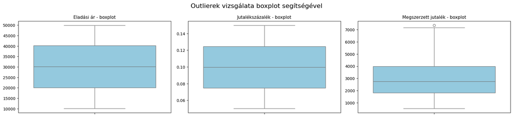

```python
variables = df.drop(columns=['Város','Eladási dátum', 'Értékesítő', 'Vásárló neve', 'Autómárka', 'Autómodell', 'Gyártási év']).columns.tolist()

fig, axes = plt.subplots(nrows=4, ncols=3, figsize=(18, 14))
axes = axes.flatten()

for i, col in enumerate(variables):
    sns.boxplot(data=df, y=col, ax=axes[i], color='skyblue')
    axes[i].set_title(f"{col} - boxplot", fontsize=11)
    axes[i].set_xlabel("")
    axes[i].set_ylabel("")

for j in range(i + 1, len(axes)):
    fig.delaxes(axes[j])

plt.tight_layout()
plt.suptitle("Outlierek vizsgálata boxplot segítségével", fontsize=16, y=1.02)

plt.show()
```

### Eredmények

1. **Eladási ár:** meglehetősen szimmetrikus a boxplot, nagyon enyhén jobbra ferde. Az medián kb. 30.000 körül van, az alsó kvartilis kb. 20.000, míg a felső kvartilis kb. 40.000 körül van. Nem jelennek meg explicit outlierek, ami arra utal, hogy nincsenek extrém kiugró értékek, az értékek eloszlása meglehetősen szabályos. LSTM architektúra tanításához nincs szükség adattisztításra.
2. **Jutalékszázalék:** a medián kb. 10%, interkvartilis tartomány: ~8% – 12.5%, míg a szórás relatíve kicsi, az értékek jellemzően 5.5% és 15% közé esnek. Ez kb. meg is felel a valóságnak olyan értelemben, hogy nem túl ingadozóak ezek a százalékok (pl. az értékesítési szabályzat egyértelműen meghatározott sávokra épül). Összességében a jutalékszázalék változó is tiszta, nincsen szükség tisztításra.
3. **Megszerzett jutalék:** a medián kicsivel alacsonyabb, mint 3.000, az interkvartilis tartomény pedig kb. 2.000 és 4.000 közé tehető. Outlierek szempotnjából azt vehetjük észre, egy-két érték kiugrik, amelyek 7.000 körüli jutalékot jeleznek. Ezek tipikus outlierek, így szükség lenne annak a vizsgálatára, hogy ezek különleges értékesítések voltak-e vagy pedig valamilyen adatbeviteli hiba okozta ezeket.

### Korrelációk vizsgálata

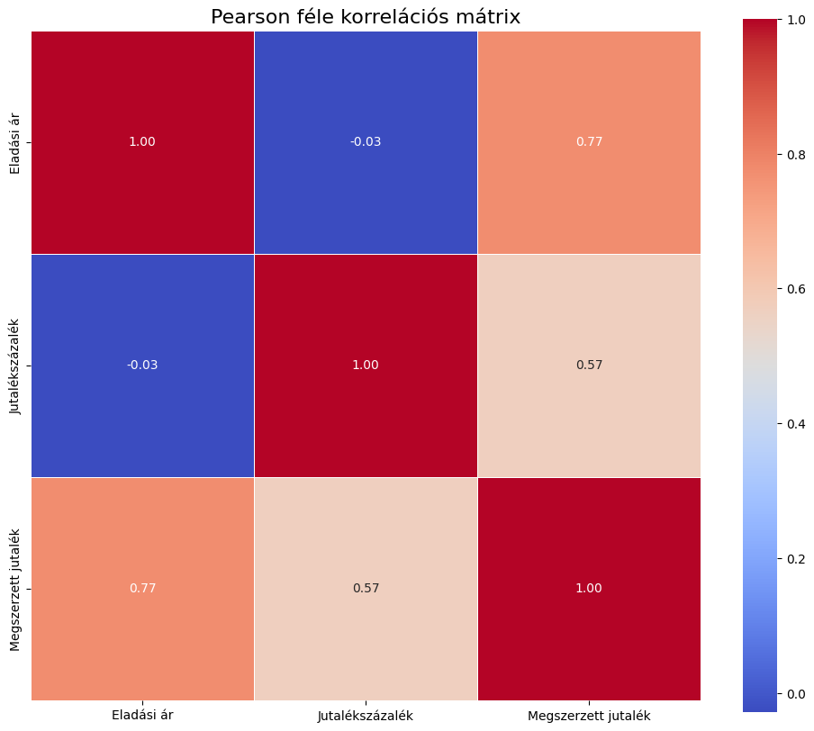

```python
# Gyártási év kizárása a korrelációs számításból
df_corr = df.drop(columns=['Gyártási év'])

# Csak numerikus értékek korrelációja
corr_matrix = df_corr.corr(numeric_only=True)

# Ábrázolás
plt.figure(figsize=(12, 10))
sns.heatmap(corr_matrix, annot=True, fmt=".2f", cmap="coolwarm", square=True, linewidths=0.5)
plt.title("Pearson féle korrelációs mátrix", fontsize=16)
plt.show()
```

### Eredmények

1. **Változók közti korrelációk**
   - **Eladási ár – Megszerzett jutalék (+0.77):** Erős pozitív korreláció fedezhető fel. Ahogy az eladási ár nő, úgy nő a megszerzett jutalék is. Ez logikus, mivel a jutalék jellemzően az ár százalékában számolódik.
   - **Jutalékszázalék – Megszerzett jutalék (+0.57):** Közepesen erős pozitív korreláció fedezhező fel. A magasabb jutalékszázalék több megszerzett jutalékhoz vezet. Ez is logikus és előre is elvárható összefüggés.
   - **Eladási ár – Jutalékszázalék (-0.03):** Gyakorlatilag nincs korreláció a kettő között. Az eladási ár nem befolyásolja a jutalékszázalékot. Ez éles esetben azt jelentheti, hogy a jutalékszázalék mindentől függetlenül van meghatározva.

### Scatter plot diagrammok

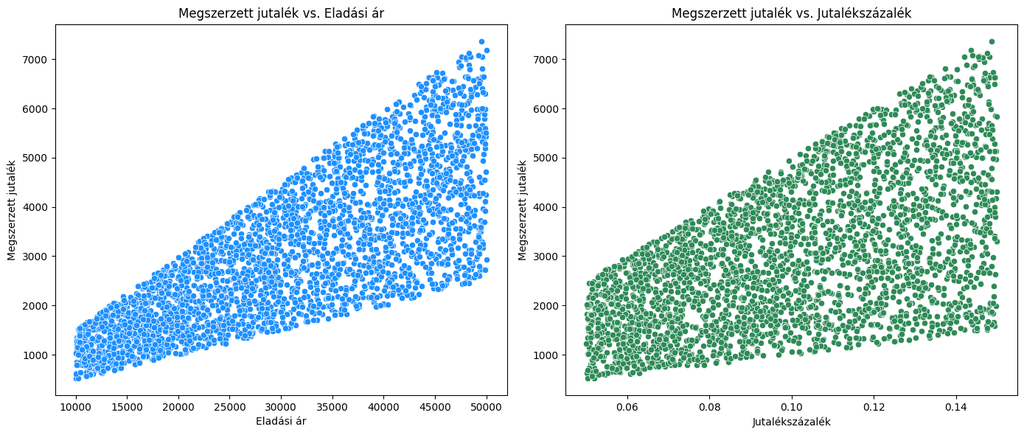

```python
plt.figure(figsize=(14, 6))

# 1. Eladási ár vs. Megszerzett jutalék
plt.subplot(1, 2, 1)
sns.scatterplot(data=df, x='Eladási ár', y='Megszerzett jutalék', color='dodgerblue')
plt.title('Megszerzett jutalék vs. Eladási ár')
plt.xlabel('Eladási ár')
plt.ylabel('Megszerzett jutalék')

# 2. Jutalékszázalék vs. Megszerzett jutalék
plt.subplot(1, 2, 2)
sns.scatterplot(data=df, x='Jutalékszázalék', y='Megszerzett jutalék', color='seagreen')
plt.title('Megszerzett jutalék vs. Jutalékszázalék')
plt.xlabel('Jutalékszázalék')
plt.ylabel('Megszerzett jutalék')

plt.tight_layout()
plt.show()
```

### Eredmények

1. **Megszerzett jutalék vs. Eladási ár:** Egyértelmű pozitív lineáris kapcsolat: ahogy nő az eladási ár, úgy nő a megszerzett jutalék is. Ez megerősíti azt, amit a korrelációs mátrixpn is láthattunk. Az eladási ár önmagában is erős prediktor lehet a megszerzett jutalék előrejelzésére.
2. **Megszerzett jutakék vs. Jutalékszázalék**: Ismét pozitív kapcsolatot láthatunk, azonban a pontok kicsit szórtabbak. Itt az eladási ár tulajdonképpen egyfajta "háttér zaj" (pl. ugyanaz a jutalékszázalék más eladási árral kombinálva mást eredményez). A jutalékszázalék önamgában nem feltétlenül határozza meg a jutalékot, viszont az eladási árral együtt igen.

### 4. LSTM modell tanítása az autók árának prediktálására

### Adatok beolvasása

```python
lstm_df1 = pd.read_csv("car_sales1.csv")
lstm_df2 = pd.read_csv("car_sales2.csv")
lstm_df3 = pd.read_csv("car_sales3.csv")

# Single dataframe
lstm_df = pd.concat([lstm_df1, lstm_df2, lstm_df3], ignore_index=True)

lstm_df
```

|  | date | city | salesperson | customername | carmake | carmodel | caryear | saleprice | commissionrate | commisionearned |
| --- | --- | --- | --- | --- | --- | --- | --- | --- | --- | --- |
| 0 | 3/26/2024 | Milwaukee | Caleb Brown | Reggis Huby | Scion | tC | 2012 | 13583 | 0.061775 | 839.089825 |
| 1 | 11/9/2024 | Omaha | Sophia Garcia | Tammy Colles | Dodge | Ram 50 | 1993 | 30803 | 0.138837 | 4276.596111 |
| 2 | 12/15/2018 | Kansas City | Thomas Ward | Rosalinda McGinley | Bentley | Continental GTC | 2007 | 38044 | 0.146159 | 5560.472996 |
| 3 | 11/11/2019 | Austin | Owen Barnes | Wendy Zywicki | Ford | E-Series | 2012 | 11452 | 0.097714 | 1119.020728 |
| 4 | 5/6/2019 | Louisville | Sebastian Flores | Linet Desaur | Mercedes-Benz | SL-Class | 1991 | 22794 | 0.149409 | 3405.628746 |
| ... | ... | ... | ... | ... | ... | ... | ... | ... | ... | ... |
| 2995 | 9/2/2024 | Colorado Springs | Michael Brown | Clemmie Durdan | Ford | Freestar | 2005 | 15513 | 0.062132 | 963.853716 |
| 2996 | 9/23/2020 | Denver | Benjamin Adams | Warden Craigg | Mercedes-Benz | CL-Class | 2000 | 33811 | 0.099843 | 3375.791673 |
| 2997 | 2/2/2020 | Arlington | Jacob Barnes | Bari Hubber | BMW | X6 | 2011 | 18288 | 0.094898 | 1735.494624 |
| 2998 | 9/10/2024 | Las Vegas | Zoey Martinez | Haleigh Trunchion | Chevrolet | Camaro | 1975 | 16666 | 0.145927 | 2432.019382 |
| 2999 | 1/8/2023 | Columbus | Abigail Price | Martina Ortelt | Toyota | Avalon | 1999 | 48346 | 0.073988 | 3577.023848 |

3000 rows × 10 columns

**Preprocessing data**

```python
# Dátum konverzió
lstm_df['date'] = pd.to_datetime(lstm_df['date'])
# Index beállítása a dátumra
lstm_df.set_index('date', inplace=True)

# Csoportosítsunk napi szinten
lstm_df = lstm_df.groupby(lstm_df.index.date).mean(numeric_only=True)

# Átalakítás vissza datetime indexre
lstm_df.index = pd.to_datetime(lstm_df.index)
```

```python
lstm_df = lstm_df.drop(['caryear'], axis = 1)

lstm_df = lstm_df.asfreq('D') # Index átállítása napi frekvenciára -> minden napra legyen egy sor (ha eredetileg nem lett volna akkor is)
lstm_df = lstm_df.ffill() # Kitölti az előző ismert értékkel az új sorok értékeit

lstm_df
```

|  | saleprice | commissionrate | commisionearned |
| --- | --- | --- | --- |
| 2018-04-19 | 12193.0 | 0.088216 | 1075.617688 |
| 2018-04-20 | 12193.0 | 0.088216 | 1075.617688 |
| 2018-04-21 | 40083.0 | 0.107946 | 4326.799518 |
| 2018-04-22 | 40083.0 | 0.107946 | 4326.799518 |
| 2018-04-23 | 28406.5 | 0.117832 | 3375.014120 |
| ... | ... | ... | ... |
| 2025-04-13 | 33595.0 | 0.140915 | 4734.039425 |
| 2025-04-14 | 37955.5 | 0.067282 | 2629.126206 |
| 2025-04-15 | 37955.5 | 0.067282 | 2629.126206 |
| 2025-04-16 | 26610.0 | 0.101302 | 2321.290402 |
| 2025-04-17 | 46123.5 | 0.057701 | 2651.380791 |

2556 rows × 3 columns

**Splitting and Scaling**

```python
# We split our dataset based on time
train_start = pd.Timestamp("2018-01-01")
valid_start = pd.Timestamp("2021-01-01")
test_start = pd.Timestamp("2024-01-01")

train_df = lstm_df[(lstm_df.index >= train_start) & (lstm_df.index < valid_start)].copy()
valid_df = lstm_df[(lstm_df.index >= valid_start) & (lstm_df.index < test_start)].copy()
test_df = lstm_df[(lstm_df.index >= test_start)].copy()
```

```python
#Scaling
scaler_input = StandardScaler()
scaler_output = StandardScaler()

scaled_train = scaler_input.fit_transform(train_df)
target_train = scaler_output.fit_transform(train_df[["saleprice"]])
scaled_valid = scaler_input.transform(valid_df)
target_valid = scaler_output.transform(valid_df[["saleprice"]])
scaled_test = scaler_input.transform(test_df)
target_test = scaler_output.transform(test_df[["saleprice"]])
```

```python
def process_Xy(raw_X: np.array, raw_y: np.array, lookback: int) -> np.array:
        X = np.empty(shape=(raw_X.shape[0] - lookback, lookback , raw_X.shape[1]), dtype=np.float32)
        y = np.empty(shape=(raw_y.shape[0] - lookback), dtype=np.float32)

        target_index = 0
        for i in range(lookback, raw_X.shape[0]):
            X[target_index] = raw_X[i - lookback : i]
            y[target_index] = raw_y[i].item()
            target_index += 1

        return X.copy(), y.copy()
```

```python
lookback = 60
train_X, train_y = process_Xy(scaled_train, target_train, lookback=lookback)
valid_X, valid_y = process_Xy(scaled_valid, target_valid, lookback=lookback)
test_X, test_y = process_Xy(scaled_test, target_test, lookback=lookback)
```

**Model Building, Training, Validating, Testing, and Visualizing**

```python
model = keras.Sequential([
    layers.LSTM(64, return_sequences=True, input_shape=train_X.shape[1:]),
    layers.Dropout(0.2),
    layers.LSTM(32),
    layers.Dense(1)
])
```

```python
model.compile(loss='MeanSquaredError', optimizer='Adam')
```

```python
model.summary()
```

```
Model: "sequential_9"
```

```
┏━━━━━━━━━━━━━━━━━━━━━━━━━━━━━━━━━━━━━━┳━━━━━━━━━━━━━━━━━━━━━━━━━━━━━┳━━━━━━━━━━━━━━━━━┓
┃ Layer (type)                         ┃ Output Shape                ┃         Param # ┃
┡━━━━━━━━━━━━━━━━━━━━━━━━━━━━━━━━━━━━━━╇━━━━━━━━━━━━━━━━━━━━━━━━━━━━━╇━━━━━━━━━━━━━━━━━┩
│ lstm_18 (LSTM)                       │ (None, 60, 64)              │          17,408 │
├──────────────────────────────────────┼─────────────────────────────┼─────────────────┤
│ dropout_9 (Dropout)                  │ (None, 60, 64)              │               0 │
├──────────────────────────────────────┼─────────────────────────────┼─────────────────┤
│ lstm_19 (LSTM)                       │ (None, 32)                  │          12,416 │
├──────────────────────────────────────┼─────────────────────────────┼─────────────────┤
│ dense_9 (Dense)                      │ (None, 1)                   │              33 │
└──────────────────────────────────────┴─────────────────────────────┴─────────────────┘
```

```
 Total params: 29,857 (116.63 KB)
```

```
 Trainable params: 29,857 (116.63 KB)
```

```
 Non-trainable params: 0 (0.00 B)
```

```python
callbacks = [EarlyStopping(monitor="val_loss", patience=20)]
```

```python
history = model.fit(
    train_X,
    train_y,
    validation_data=(valid_X, valid_y),
    batch_size=16,
    epochs=100,
    callbacks=callbacks,
    shuffle=False,
    verbose=True,
)
```

```
58/58 ━━━━━━━━━━━━━━━━━━━━ 5s 45ms/step - loss: 0.9824 - val_loss: 0.9496
58/58 ━━━━━━━━━━━━━━━━━━━━ 2s 37ms/step - loss: 0.9534 - val_loss: 0.9394
58/58 ━━━━━━━━━━━━━━━━━━━━ 2s 34ms/step - loss: 0.9235 - val_loss: 0.9286
58/58 ━━━━━━━━━━━━━━━━━━━━ 2s 36ms/step - loss: 0.9005 - val_loss: 0.9160
58/58 ━━━━━━━━━━━━━━━━━━━━ 2s 34ms/step - loss: 0.8759 - val_loss: 0.9118
58/58 ━━━━━━━━━━━━━━━━━━━━ 2s 33ms/step - loss: 0.8664 - val_loss: 0.8975
58/58 ━━━━━━━━━━━━━━━━━━━━ 2s 34ms/step - loss: 0.8486 - val_loss: 0.8919
58/58 ━━━━━━━━━━━━━━━━━━━━ 2s 35ms/step - loss: 0.8511 - val_loss: 0.8926
58/58 ━━━━━━━━━━━━━━━━━━━━ 2s 38ms/step - loss: 0.8481 - val_loss: 0.8910
58/58 ━━━━━━━━━━━━━━━━━━━━ 2s 39ms/step - loss: 0.8352 - val_loss: 0.8931
58/58 ━━━━━━━━━━━━━━━━━━━━ 2s 34ms/step - loss: 0.8389 - val_loss: 0.8912
58/58 ━━━━━━━━━━━━━━━━━━━━ 2s 38ms/step - loss: 0.8323 - val_loss: 0.8944
58/58 ━━━━━━━━━━━━━━━━━━━━ 2s 38ms/step - loss: 0.8250 - val_loss: 0.8986
58/58 ━━━━━━━━━━━━━━━━━━━━ 2s 38ms/step - loss: 0.8196 - val_loss: 0.8960
58/58 ━━━━━━━━━━━━━━━━━━━━ 2s 35ms/step - loss: 0.8135 - val_loss: 0.9101
58/58 ━━━━━━━━━━━━━━━━━━━━ 2s 34ms/step - loss: 0.8276 - val_loss: 0.9162
58/58 ━━━━━━━━━━━━━━━━━━━━ 2s 34ms/step - loss: 0.8189 - val_loss: 0.9236
58/58 ━━━━━━━━━━━━━━━━━━━━ 2s 33ms/step - loss: 0.8266 - val_loss: 0.9315
58/58 ━━━━━━━━━━━━━━━━━━━━ 2s 34ms/step - loss: 0.8210 - val_loss: 0.9180
58/58 ━━━━━━━━━━━━━━━━━━━━ 2s 37ms/step - loss: 0.7952 - val_loss: 0.9521
58/58 ━━━━━━━━━━━━━━━━━━━━ 2s 33ms/step - loss: 0.7677 - val_loss: 0.9580
58/58 ━━━━━━━━━━━━━━━━━━━━ 2s 33ms/step - loss: 0.7847 - val_loss: 0.9818
58/58 ━━━━━━━━━━━━━━━━━━━━ 2s 33ms/step - loss: 0.7713 - val_loss: 0.9684
58/58 ━━━━━━━━━━━━━━━━━━━━ 2s 35ms/step - loss: 0.8052 - val_loss: 0.9585
58/58 ━━━━━━━━━━━━━━━━━━━━ 2s 34ms/step - loss: 0.7541 - val_loss: 0.9862
58/58 ━━━━━━━━━━━━━━━━━━━━ 2s 34ms/step - loss: 0.7206 - val_loss: 1.0279
58/58 ━━━━━━━━━━━━━━━━━━━━ 2s 37ms/step - loss: 0.7569 - val_loss: 0.9933
58/58 ━━━━━━━━━━━━━━━━━━━━ 2s 34ms/step - loss: 0.7560 - val_loss: 1.0495
58/58 ━━━━━━━━━━━━━━━━━━━━ 2s 34ms/step - loss: 0.7346 - val_loss: 1.0334
```

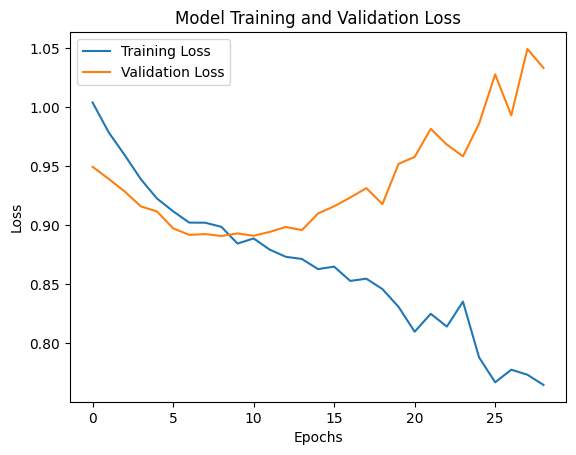

```python
plt.plot(history.history['loss'], label='Training Loss')
plt.plot(history.history['val_loss'], label='Validation Loss')
plt.title('Model Training and Validation Loss')
plt.xlabel('Epochs')
plt.ylabel('Loss')
plt.legend()
plt.show()
```

```
13/13 ━━━━━━━━━━━━━━━━━━━━ 1s 30ms/step
```

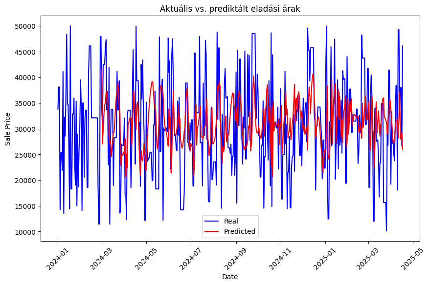

```python
pred = model.predict(test_X)
pred_rescaled = scaler_output.inverse_transform(pred)
plt.figure(figsize=(10, 6))
plt.plot(test_df["saleprice"], label="Real", color='blue')
plt.plot(pd.DataFrame(index=test_df.index[lookback:], data=scaler_output.inverse_transform(pred)), label="Predicted", color='red')
plt.xticks(rotation=45)
plt.title('Aktuális vs. prediktált eladási árak')
plt.xlabel('Date')
plt.ylabel('Sale Price')
plt.legend()
plt.show()
```

### Tapasztalatok, észrevételek

A tapasztalatom az volt az LSTM modell tanítása során, hogy sajnos az adataim nem megfelelőek ahhoz, hogy idősoros előrejelzést lehessen adni velük. Eleinte nagyon messze volt egymástól az aktuális és a prediktált ár, azonban ezen sikerült valamennyit javítani, ugyanakkor továbbra sem tökéletes a predikció. Ez főként szerintem annak köszönhető, hogy nem is volt minden egyes dátumra adat az első és az utolsó minta dátuma között, illetve az autók árainak randomizáltsága sem segített abban, hogy egyszerűb legyen tanítani a modellt.